# p8105_hw5_cgd2137

Carolina Downie

11/1/2017

```r
library(ggplot2)
library(tidyverse)
library(rvest)
library(httr)
library(stringr)
library(janitor)
library(haven)
library(stringr)
library(forcats)
library(tidytext)
library(viridis)
knitr::opts_chunk$set(
  fig.width = 11,
  fig.asp = .6,
  out.width = "90%")
```

# Problem 1–Subway entrances in NYC subways:

```r
nyc_subway <- GET("https://data.ny.gov/resource/hvwh-qtfg.json", query = list("$limit" = 2000)) %>%
  content("text") %>%
  jsonlite::fromJSON() %>%
  select(station_name, north_south_street, east_west_street, entrance_latitude, entrance_longitude, corner)
```

Making a plot showing the number of entrances for each subway station (restricted to stations that have more than 10 entrances).

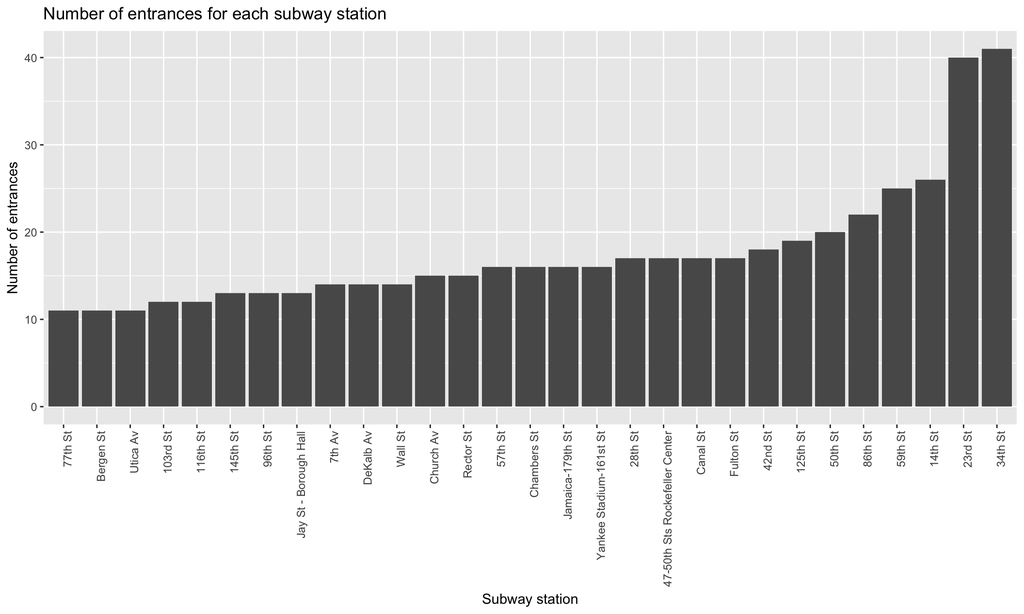

```r
nyc_subway %>% group_by(station_name) %>%
  mutate(num_entrances = n()) %>%
  filter(num_entrances > 10) %>%
  select(station_name, num_entrances) %>%
  unique(.) %>%
  ggplot(aes(x = forcats::fct_reorder(station_name, num_entrances), y = num_entrances, group = station_name)) +
    geom_bar(stat = "identity") + labs(
    title = "Number of entrances for each subway station",
    x = "Subway station",
    y = "Number of entrances") +
    theme(axis.text.x = element_text(angle = 90, hjust = 1))
```

Calculating the number of stations with names containing “St” and ending in “St”:

```r
nyc_subway_contains_st<-nyc_subway %>% filter(str_detect(station_name, "St"))
```

There are 176 subway stations containing “St” in their name.

```r
nyc_subway_ends_St<-nyc_subway_contains_st %>%
  pull(station_name) %>%
  str_locate(., "St") %>%
  data.frame() %>%
  cbind(., nyc_subway_contains_st) %>%
  filter(end == str_length(station_name))
```

There are 138 subway stations with names ending in “St”.

# Problem 2–Game of Thrones viewers:

```r
url<- "https://en.wikipedia.org/wiki/Game_of_Thrones#cite_note-S3ratings-277"

ratings_xml <- (read_html(url) %>% html_nodes(css = "table"))[[4]] %>% html_table(header = TRUE) %>% data.frame()
```

Tidying dataset to include variables for season, episode, viewers, and a unique episode ID of the form SX_EYY where X and Y are season or episode numbers.

```r
GoT_ratings <- ratings_xml %>% select(-c(Average, Season)) %>%
  rename(season = Season.1) %>%
  gather(key = episode, value = num_viewers, Ep..1: Ep..10) %>%
  separate(episode, c("remove", "episode"), "\\..") %>%
  select(-remove) %>%
  filter(num_viewers != "N/A") %>%
  mutate(episode_id = paste("S",substr(season, 1,1), "_","E",substr(episode, 1, 2)), num_viewers = as.numeric(num_viewers))
```

Making a plot that shows the number of viewers for each episode of each season.

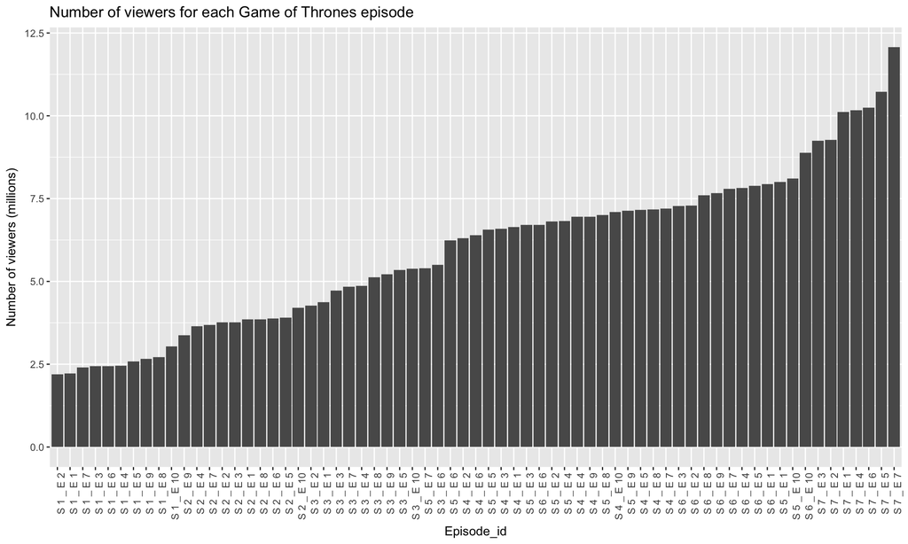

```r
GoT_ratings %>%
  mutate(episode_id = fct_reorder(episode_id, num_viewers)) %>%
  ggplot(aes(x = episode_id, y = num_viewers)) +
  geom_bar(stat = "identity") +
  labs(
    title = "Number of viewers for each Game of Thrones episode",
    x = "Episode_id",
    y = "Number of viewers (millions)") +
  theme(legend.position = "bottom") + theme(axis.text.x = element_text(angle = 90, hjust = 1))
```

Making a boxplot of the number of viewers for each episode (across all 7 seasons).

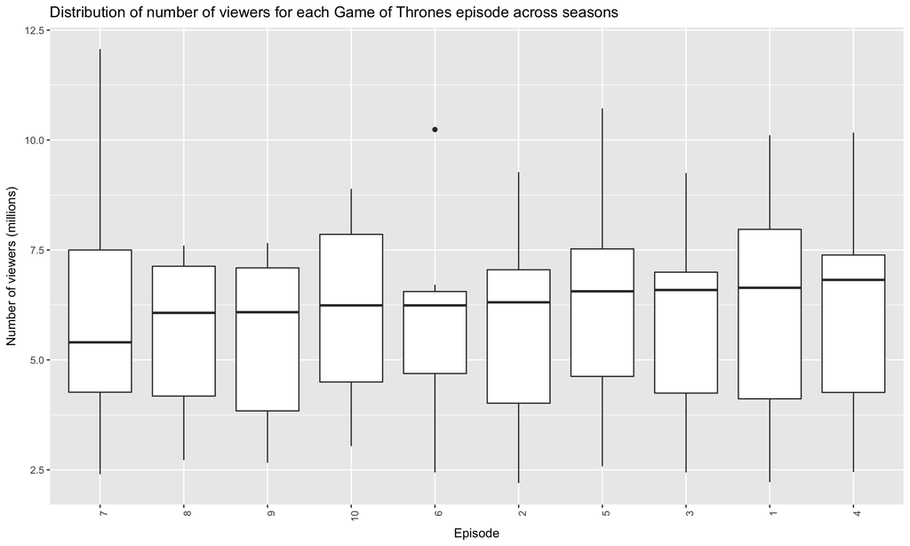

```r
GoT_ratings %>%
  mutate(episode = fct_reorder(episode, num_viewers)) %>%
  ggplot(aes(x = episode, y = num_viewers)) +
  geom_boxplot() +
  labs(
    title = "Distribution of number of viewers for each Game of Thrones episode across seasons",
    x = "Episode",
    y = "Number of viewers (millions)") +
  theme(legend.position = "bottom") + theme(axis.text.x = element_text(angle = 90, hjust = 1))
```

Fitting a linear model that treats number of viewers in each episode as a response and season as a categorical predictor (season 4 is reference)

```r
GoT_ratings %>%
  mutate(season = as.factor(season), season = fct_relevel(season, "4")) %>%
  lm(num_viewers ~ season, data = .) %>%
  broom::tidy() %>%
  select(-std.error, -statistic) %>%
  knitr::kable(digits = 3)
```

| term | estimate | p.value |
| --- | --- | --- |
| (Intercept) | 6.846 | 0.000 |
| season1 | -4.331 | 0.000 |
| season2 | -3.051 | 0.000 |
| season3 | -1.880 | 0.000 |
| season5 | 0.034 | 0.889 |
| season6 | 0.842 | 0.001 |
| season7 | 3.415 | 0.000 |

This linear model suggests that for seasons 1, 2, and 3, season had a negative relationship with number of viewers, whereas for seasons 5, 6, and 7, season had a positive relationship with number of viewers (when season 4 was used as the reference group). Season 7 has the largest estimated beta value.

# Problem 3–sentiment analysis of Napolean Dynamite reviews:

```r
dynamite_reviews <- read_csv("dynamite_reviews.csv")
```

The dataset created by this procedure contains 3 variables: title, stars, and text. Title stores the initial text that accompanies the star rating, stars stores information about how many stars the reviewer gave, and text stores the additional comments found below the star rating on the Amazon website. However, the titles are non-unique; for example, multiple reviewers titled their reviews “Five Stars”. This will likely cause issues when we try to analyze the dataset, so another variable with the unique review number should be added:

```r
dynamite_reviews <- dynamite_reviews %>% mutate(review_num = c(1:nrow(dynamite_reviews))) %>% select(review_num, title, stars, text)
```

Creating a tidy text dataset from the above using the text in the reviews, removing stop words and using words as the token.

```r
ratings_tidy_text<- dynamite_reviews %>% unnest_tokens(word, text)

data(stop_words)

ratings_tidy_text <- anti_join(ratings_tidy_text, stop_words)
```

What words are most frequently used in five-star reviews? In 1-star reviews?

```r
words_5_stars<-ratings_tidy_text %>%
  filter(stars == "5") %>%
  pull(word) %>%
  table() %>%
  data.frame() %>%
  arrange(desc(Freq)) %>%
  rename(words = ".") %>%
  top_n(., 5)
words_1_star<-ratings_tidy_text %>%
  filter(stars == "1") %>%
  pull(word) %>%
  table() %>%
  data.frame() %>%
  arrange(desc(Freq)) %>%
  rename(words = ".") %>%
  top_n(., 5)
```

The top 5 most common words used in five-star reviews are movie, love, funny, classic, watch. The top 5 most common words used in one-star reviews are movie, dvd, watch, time, bad, dumb (Note: there may be more than 5 words for each of these if there is a tie in the frequency of most common words).

Making a plot that shows the (approximate) log odds ratio for word appearance comparing 1-star reviews to 5-star reviews, including the 10 words with the most extreme log ORs in both directions.

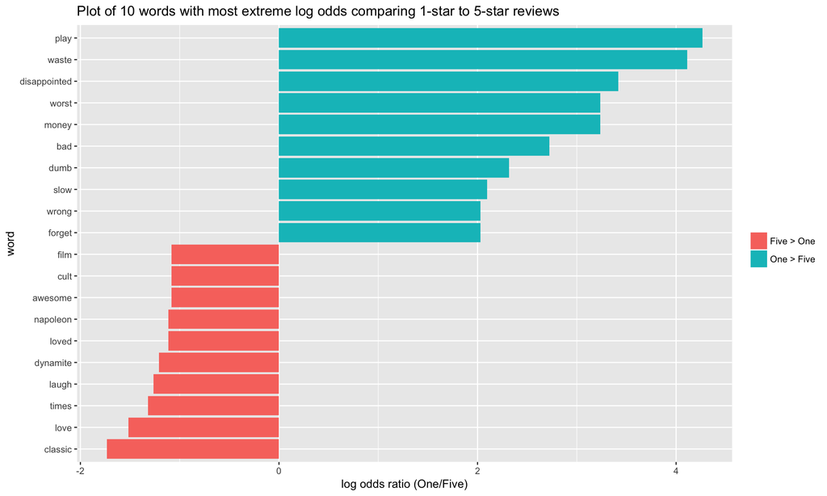

```r
#Calculating log odds ratio
ratings_word_ratios <- ratings_tidy_text %>%
  mutate(stars = as.character(stars)) %>%
  filter(stars %in% c("1", "5")) %>%
  count(word, stars) %>%
  group_by(word) %>%
  filter(sum(n) >= 5) %>%
  ungroup() %>%
  spread(stars, n, fill = 0) %>%
  rename(One = "1", Five = "5") %>%
  mutate(
   One_odds = (One + 1) / (sum(One) + 1),
    Five_odds = (Five + 1) / (sum(Five) + 1),
    log_OR = log(One_odds / Five_odds)
  ) %>%
  arrange(desc(log_OR))

#Plotting the 10 words with the most extreme log odds
ratings_word_ratios %>%
  mutate(pos_log_OR = ifelse(log_OR > 0, "One > Five", "Five > One")) %>%
  group_by(pos_log_OR) %>%
  top_n(10, abs(log_OR)) %>%
  ungroup() %>%
  mutate(word = fct_reorder(word, log_OR)) %>%
  ggplot(aes(word, log_OR, fill = pos_log_OR)) +
  geom_col() +
  coord_flip() +
  ylab("log odds ratio (One/Five)") +
  scale_fill_discrete(name = "") +
  labs(
    title = "Plot of 10 words with most extreme log odds comparing 1-star to 5-star reviews"
  )
```

Conducting a sentiment analysis of ratings by star ratings

```r
bing_sentiments <- get_sentiments("bing")

#Need to add review number because not all titles are unique.
ratings_sentiments <- ratings_tidy_text %>%
  inner_join(., bing_sentiments) %>%
  count(review_num, sentiment) %>%
  spread(sentiment, n, fill = 0) %>%
  mutate(sentiment = positive - negative) %>%
  select(review_num, sentiment)
```

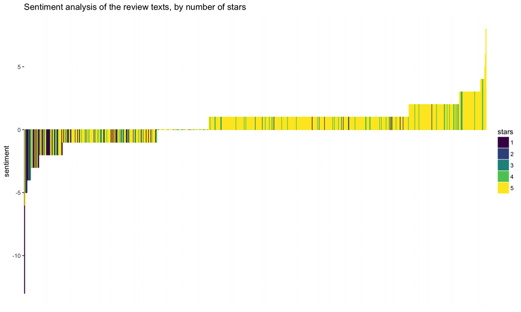

```r
ratings_sentiments <- right_join(dynamite_reviews, ratings_sentiments, by = "review_num")

ratings_sentiments %>%
  mutate(review_num = factor(review_num),
    review_num = fct_reorder(review_num, sentiment),
    stars = as.factor(stars)) %>%
  ggplot(aes(x = review_num,
             y = sentiment, fill = stars, color = stars)) +
  geom_bar(stat = "identity") +
  theme(axis.title.x = element_blank(),
        axis.text.x = element_blank(),
        axis.ticks.x = element_blank()) +
  scale_fill_viridis(discrete = TRUE) +
  scale_color_viridis(discrete = TRUE) +
  labs(
    title = "Sentiment analysis of the review texts, by number of stars"
  )
```

```r
most_positive_review <- ratings_sentiments %>% filter(sentiment == max(sentiment))

most_neg_review <- ratings_sentiments %>% filter(sentiment == min(sentiment))
```

The most positive review(s) was review number 642, with a sentiment score of 8.

The most negative review(s) was review number 537, with a sentiment score of -13.